# Curso I – SISSA

Ejercicio 2

## Bienvenida/o

Bienvenida/o al segundo ejercicio práctico del *Taller de fusión de datos satelitales con estaciones*. ¡Esperamos que esté listo para probar algunas cosas!

Este tutorial está compuesto por tres ejercicios:

- Pre-procesamiento de MOD16 Ea
- Agregar SSEBop
- Análisis de series de tiempo

Después de completar este tutorial, podrás pre-procesar datos en grilla, agregar datos en grilla a múltiples resoluciones temporales y trabajar con series de tiempo en R.

## Pre-procesamiento de MOD16 Ea

El conjunto de datos MOD16A2 (Mu et al. 2007; Mu, Zhao, y Running 2011) es un producto compuesto de 8-días con una resolución espacial de 500 m. El algoritmo se basa en la ecuación de Penman-Monteith y utiliza datos de reanálisis meteorológico diario (presión atmosférica, temperatura del aire, humedad y radiación) en combinación con productos obtenidos por teledetección de MODIS, como albedo, cobertura del suelo y dinámica de propiedades de vegetación. Este conjunto de datos proporciona evaporación actual (Ea) y evaporación potencial (PET), que representan la suma de la pérdida de agua total de 8 días a través de Ea (0,1 kg m -2 8-días -1), mientras que sus flujos de calor latente asociados (LE y PLE, respectivamente) son la energía total promedio sobre una unidad de área por día (durante el período de 8 días designado; Running et al. 2017).

La Tabla 1 muestra información sobre las variables proporcionadas por MOD16A2. Para obtener los valores correctos de una variable, debes multiplicar los datos brutos por el factor de escala correspondiente. Esto significa que el producto debe escalarse (en este caso, por un factor multiplicador: factor de escala) para obtener el valor correcto. Ten en cuenta que dichos factores de escala son comunes en algunos conjuntos de datos. Esto para que el tamaño del archivo de datos brutos se reduzca. En este caso, los valores de Ea se guardan como enteros de -32767 a 32767. Como aquellos con experiencia en informática pueden reconocer, 2 elevado a la potencia de 16 es igual a 65538 (esta es la longitud del rango de datos válidos, incluyendo los valores donde no se calcula evaporación), por lo tanto, el valor de cada celda se puede guardar en 16 bits.

Tabla 1: Información detallada del producto MOD16A2.

| Producto | Significado | Unidades | Tipo de datos | Rango | Factor de escala |
| --- | --- | --- | --- | --- | --- |
| ET_500m | 8-días total Ea | kg m$^{-2}$ 8d$^{-1}$ | int16 | -32767 $\sim$ 32767 | 0.1 |
| LE_500m | 8-días promedio LE | J m$^{-2}$ d$^{-1}$ | int16 | -32767 $\sim$ 32767 | 10000 |
| PET_500m | 8-días total PET | kg m$^{-2}$ 8d$^{-1}$ | int16 | -32767 $\sim$ 32767 | 0.1 |
| PLE_500m | 8-días promedio PLE | J m$^{-2}$ d$^{-1}$ | int16 | -32767 $\sim$ 32767 | 10000 |
| ET_QC_500m | Control de calidad | - | unit8 | 0 $\sim$ 254 | - |

Además, existen 7 valores para celdas sin vegetación en donde no se calcula la Ea (Running et al. 2017). Estos valores son:

1. Fuera de la Tierra = 32767
2. Cuerpos de agua = 32766
3. Áreas sin vegetación o escasamente vegetadas = 32765
4. Nieve y hielo permanente = 32764
5. Humedales permanentes = 32763
6. Áreas urbanas o construidas = 32762
7. Sin clasificar = 32761

### Objetivo de la tarea

El estudiante debe ser capaz de leer un archivo MOD16A2 crudo (proporcionado con este ejercicio) y procesarlo para obtener valores de Ea.

1. Obtener un archivo ráster donde Ea se exprese en mm acumulados durante el período de 8 días y todas las celdas de la cuadrícula sin Ea se almacenen como NAs.
2. Exportar el ráster preprocesado a una carpeta específica.

### Solución

**Paso 1:** tenemos que leer el archivo raster.

```r
library(terra)
modis_path <- "C:/Users/obaezvil/Data/Part_1/MOD16A2_ET_500m_2018_361.tif"
```

```r
modis_path <- "../Data/Exercise_2/Part_1/MOD16A2_ET_500m_2018_361.tif"
```

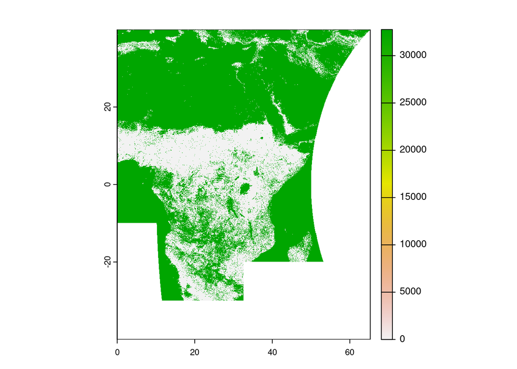

```r
modis <- rast(modis_path)
plot(modis)
```

**Paso 2:** ahora que hemos leído el raster, podemos establecer las celdas no vegetadas (y otras celdas no clasificadas) como NAs. Recuerde que las celdas no vegetadas se representaron mediante valores iguales o mayores que 32761.

```r
modis[modis >= 32761] <- NA
```

```
##
|---------|---------|---------|---------|
=========================================


|---------|---------|---------|---------|
=========================================
```

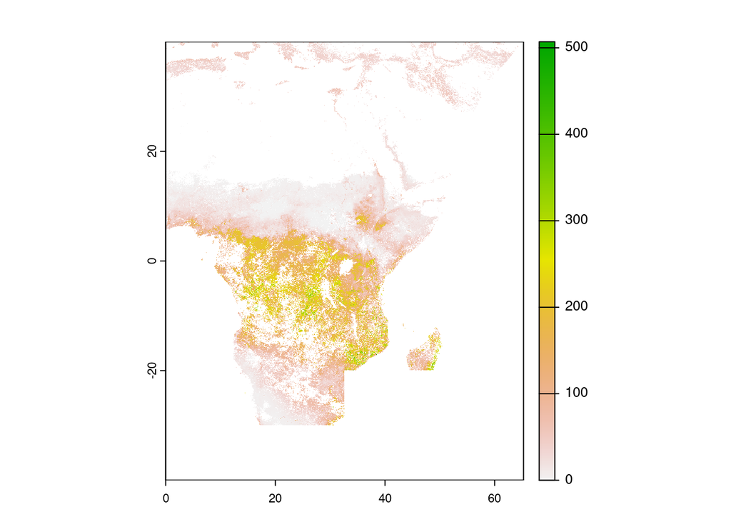

```r
plot(modis)
```

¿Por qué son tan altos los valores? Porque se necesita aplicar un factor de escala a los datos en bruto para obtener los valores Ea (consulte la Tabla 1).

**Paso 3:** se debe aplicar un factor de escala de 0.1 al conjunto de datos ET_500m.

```r
modis <- modis * 0.1
```

```
##
|---------|---------|---------|---------|
=========================================
```

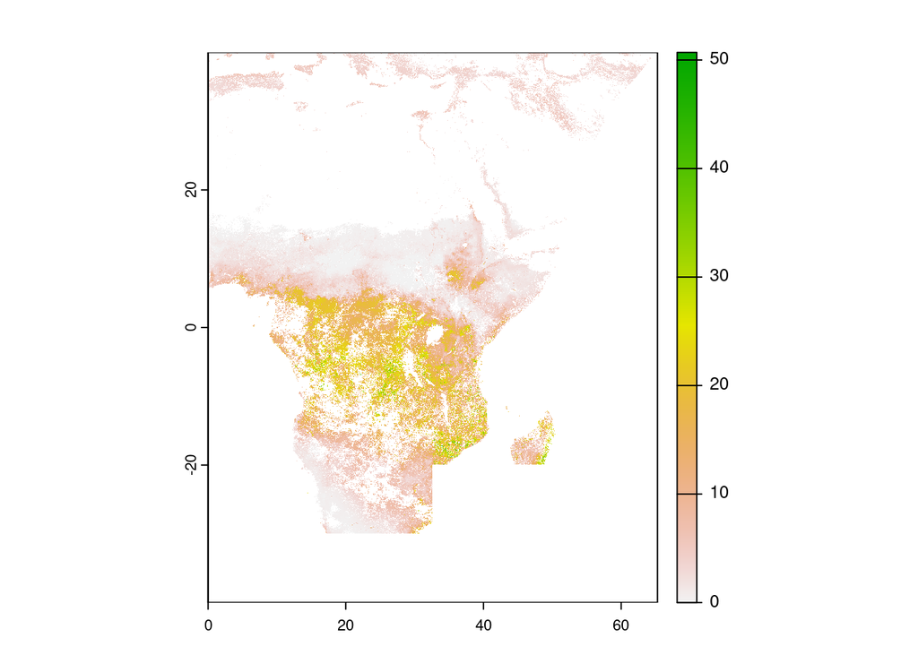

```r
plot(modis)
```

Siempre considere el orden en que realiza operaciones en una matriz. Si hubiéramos aplicado el factor de escala primero y luego buscado celdas con un valor mayor o igual a 32761, no habríamos asignado a las celdas relevantes valores de NA.

**Paso 4:** para exportar el raster preprocesado, podemos usar la función **writeRaster**.

```r
output <- "C:/Users/obaezvil/Data/Exercise_1/Results"
writeRaster(modis, file.path(output, "MODIS_processed_2018_361.tif"),
overwrite = TRUE)
```

## Agregar SSEBop

El producto operativo Simplified Surface Energy Balance (SSEBop; Senay et al. 2013) combina fracciones de Ea generadas a partir de imágenes térmicas MODIS con evaporación de referencia utilizando un enfoque de índice térmico para generar estimaciones de Ea de 10 días en milímetros. Este producto utiliza condiciones límite predefinidas y estacionalmente dinámicas que son únicas para cada celda de la cuadrícula para los puntos de referencia frío/húmedo (cold/wed) y caliente/seco (hot/dry). En SSEBop, cada mes se divide en tres periodos de tiempo: $i)$ los primeros 10 días; $ii)$ los segundos 10 días; y $iii)$ los días restantes desde el 21 hasta el final del mes.

### Objetivo de la tarea

El estudiante debe procesar los 10 días de SSEBop para obtener valores de Ea mensuales recortados a la extensión de Ruanda para 2009-2011. Los rásters mensuales derivados deben guardarse en una nueva carpeta (con información sobre el año y el mes en el nombre del archivo). Para este ejercicio, se proporcionan archivos ráster de SSEBop de 10 días (de 2008 a 2013). La Figura 1 muestra los primeros 16 archivos ráster de SSEBop de 10 días proporcionados, mientras que la Figura 2 muestra el archivo de forma donde se debe hacer el subconjunto de Ruanda.

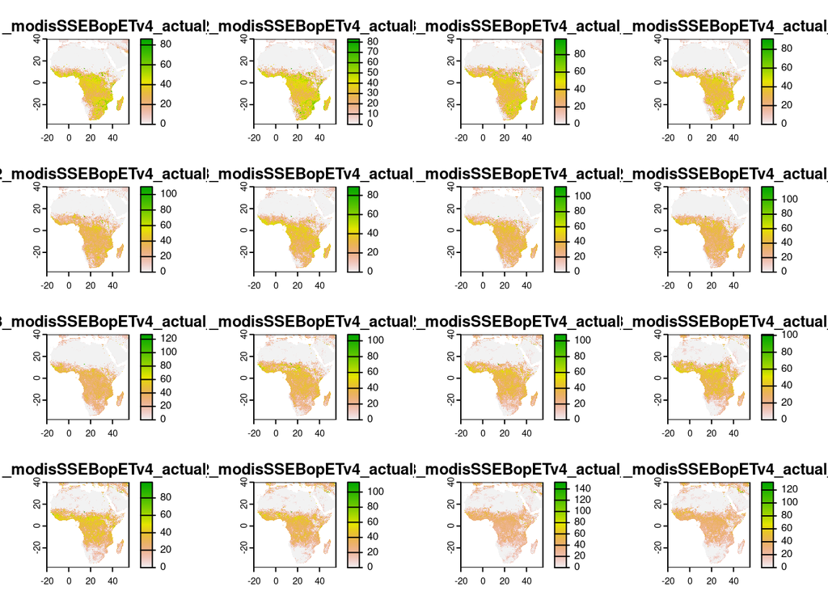

Figure 1: First 16 SSEBop raster files provided

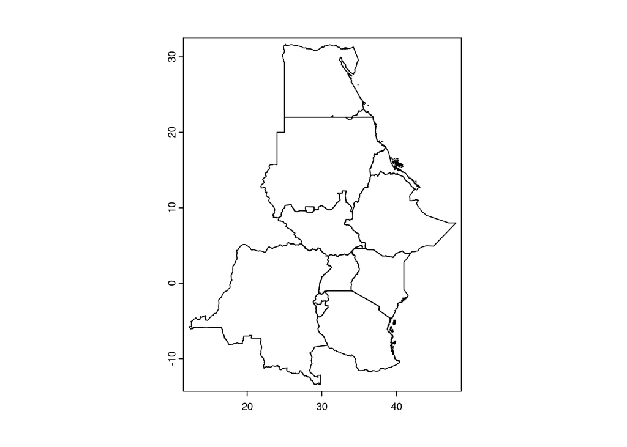

Figure 2: Shapefile of the Nile Basin countries

### Solución

**Paso 1:** Primero, carguemos los paquetes que utilizaremos.

```r
library(terra)
```

**Paso 2:** Debemos almacenar las rutas que utilizaremos: $i)$ la de los archivos SSEBop; $ii)$ la del shapefile; y $iii)$ la ruta donde se almacenarán los archivos de salida.

```r
ssebop     <- "C:/Users/Data/1BSU_2/SSEBop"
shape_path <- "C:/Users/Data/1BSU_2/Countries/Nile_Basin_Countries_GAUL2014_2.shp"
output     <- "C:/Users/Data/Results/SSEBop"
```

**Paso 3:** Listemos los archivos en la carpeta ssebop.

```r
files <- list.files(ssebop, full.names = TRUE)
head(files)
```

```
## [1] "../Data/Exercise_2/Part_2/SSEBop/d2008011_modisSSEBopETv4_actual_mm.tif"
## [2] "../Data/Exercise_2/Part_2/SSEBop/d2008012_modisSSEBopETv4_actual_mm.tif"
## [3] "../Data/Exercise_2/Part_2/SSEBop/d2008013_modisSSEBopETv4_actual_mm.tif"
## [4] "../Data/Exercise_2/Part_2/SSEBop/d2008021_modisSSEBopETv4_actual_mm.tif"
## [5] "../Data/Exercise_2/Part_2/SSEBop/d2008022_modisSSEBopETv4_actual_mm.tif"
## [6] "../Data/Exercise_2/Part_2/SSEBop/d2008023_modisSSEBopETv4_actual_mm.tif"
```

**Paso 4:** En este Paso, la función *grep(“2009”, basename(files))* devolverá las posiciones de los 36 archivos correspondientes a 2009 dentro de la lista de archivos. Eso significa que *min(grep(“2009”, basename(files)))* devolverá la posición del primer archivo del 2009 (en este caso será la posición 37, porque las posiciones 1 a 36 son los archivos de 2008). De manera similar, *max(grep(“2011”, basename(files)))* devolverá la posición del último archivo del 2011. Eso significa que *files[start:end]* devolverá el subconjunto de archivos que están en las posiciones 37 a 144.´

```r
# creamos un vector de posiciones 'start:end' para todos los archivos
# que contienen 2009, 2010 y 2011
start <- min(grep("200901", basename(files)))
end   <- max(grep("201112", basename(files)))
files <- files[start:end]
head(files)
```

```
## [1] "../Data/Exercise_2/Part_2/SSEBop/d2009011_modisSSEBopETv4_actual_mm.tif"
## [2] "../Data/Exercise_2/Part_2/SSEBop/d2009012_modisSSEBopETv4_actual_mm.tif"
## [3] "../Data/Exercise_2/Part_2/SSEBop/d2009013_modisSSEBopETv4_actual_mm.tif"
## [4] "../Data/Exercise_2/Part_2/SSEBop/d2009021_modisSSEBopETv4_actual_mm.tif"
## [5] "../Data/Exercise_2/Part_2/SSEBop/d2009022_modisSSEBopETv4_actual_mm.tif"
## [6] "../Data/Exercise_2/Part_2/SSEBop/d2009023_modisSSEBopETv4_actual_mm.tif"
```

```r
tail(files)
```

```
## [1] "../Data/Exercise_2/Part_2/SSEBop/d2011111_modisSSEBopETv4_actual_mm.tif"
## [2] "../Data/Exercise_2/Part_2/SSEBop/d2011112_modisSSEBopETv4_actual_mm.tif"
## [3] "../Data/Exercise_2/Part_2/SSEBop/d2011113_modisSSEBopETv4_actual_mm.tif"
## [4] "../Data/Exercise_2/Part_2/SSEBop/d2011121_modisSSEBopETv4_actual_mm.tif"
## [5] "../Data/Exercise_2/Part_2/SSEBop/d2011122_modisSSEBopETv4_actual_mm.tif"
## [6] "../Data/Exercise_2/Part_2/SSEBop/d2011123_modisSSEBopETv4_actual_mm.tif"
```

**Paso 5:** Para leer el shapefile, tenemos que usar la función **vect** del paquete **terra**.

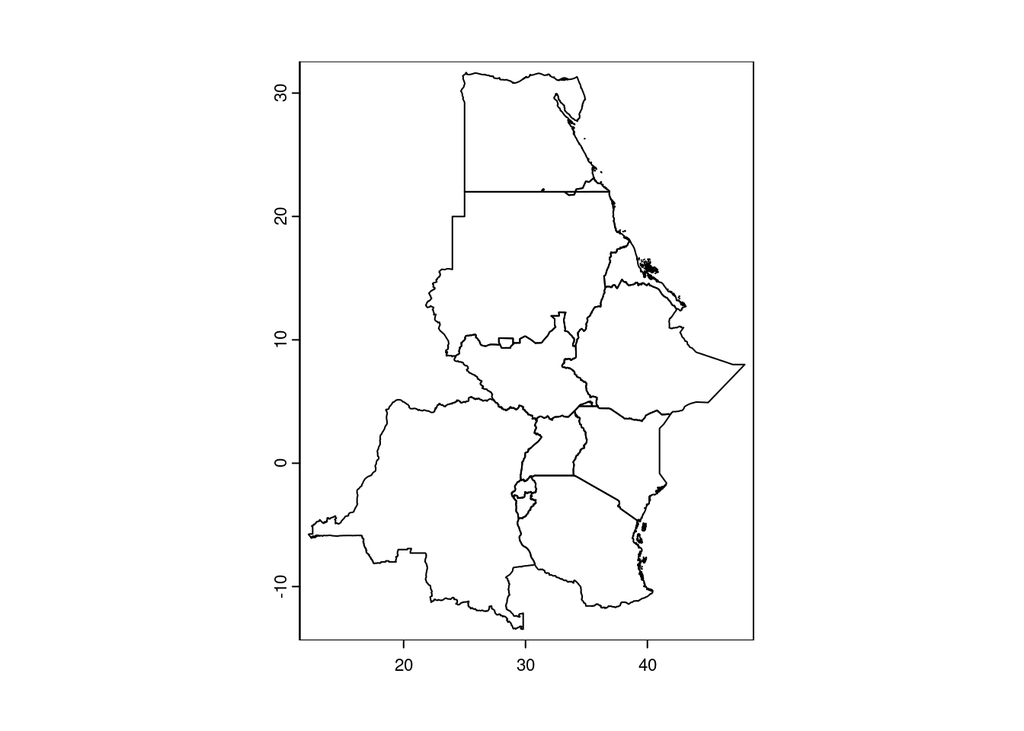

```r
nile_countries <- vect(shape_path)
plot(nile_countries, axes = TRUE)
```

**Paso 6:** Para subconjuntar Ruanda del shapefile *nile.countries*, primero imprimimos la tabla de atributos para ver a qué elemento/posición corresponde.

```r
values(nile_countries)
```

```
##                   STATUS DISP_AREA ADM0_CODE                        ADM0_NAME
## 1           Member State        NO       205                           Rwanda
## 2           Member State        NO       133                            Kenya
## 3           Member State        NO        74                      South Sudan
## 4           Member State        NO       257      United Republic of Tanzania
## 5           Member State        NO       253                           Uganda
## 6  Sovereignty unsettled       YES     61013                   Ilemi triangle
## 7           Member State        NO        79                         Ethiopia
## 8           Member State        NO        77                          Eritrea
## 9           Member State        NO        43                          Burundi
## 10          Member State        NO        68 Democratic Republic of the Congo
## 11 Sovereignty unsettled       YES     40760                 Hala'ib triangle
## 12 Sovereignty unsettled       YES     40762                  Ma'tan al-Sarra
## 13          Member State        NO         6                            Sudan
## 14          Member State        NO     40765                            Egypt
```

[output cut: 17 more lines]

**Paso 7:** La información para Ruanda se encuentra en la primera fila de la tabla; por lo tanto, tenemos que extraer la información de la primera fila.

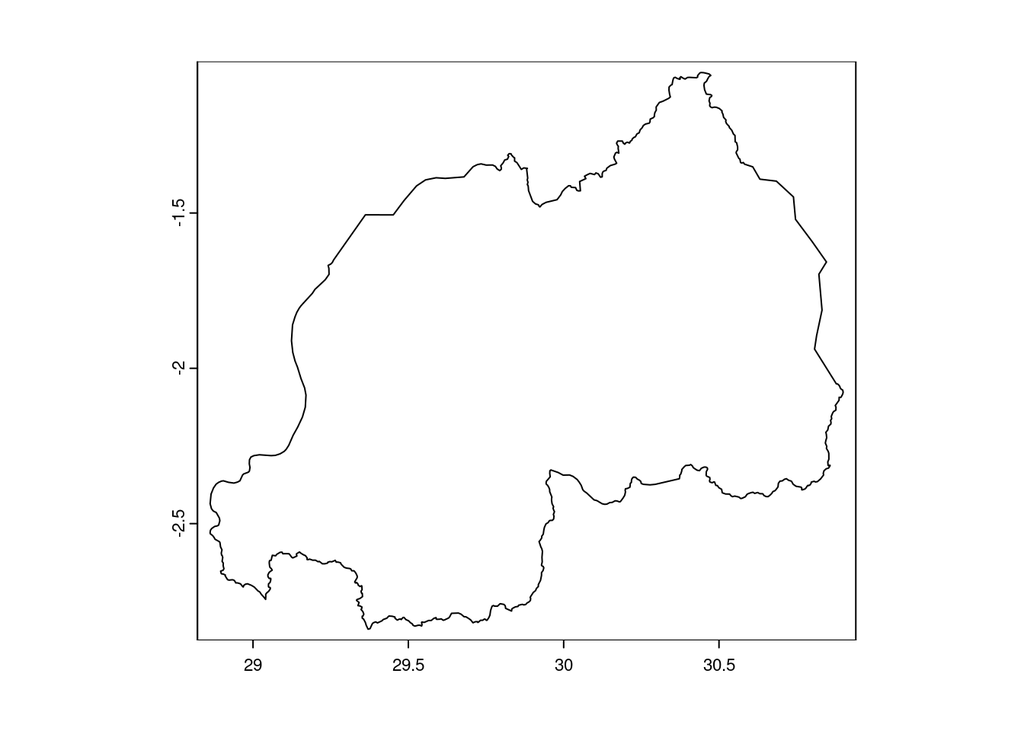

```r
rwanda <- nile_countries[1,]
plot(rwanda, axes = TRUE)
```

**Paso 8:** Obtengamos los años y meses de cada archivo a partir de los nombres de archivo.

```r
# Recuerda que los números 2 y 8 representan la posición del primer
# y último carácter donde se almacenan las fechas.

# La posición 6 y 7 se refiere al mes y la posición del caracter 8 se refiere
# a cuál periodo de 10 dias está relacionado con la capa.

dates <- substr(basename(files), 2, 7)
head(dates)
```

```
## [1] "200901" "200901" "200901" "200902" "200902" "200902"
```

**NOTA:** La función unique devuelve los valores que se incluyen en un objeto sin repetición (es decir, valores únicos).

**Paso 9:** El producto SSEBop proporciona tres archivos ráster por mes; por lo tanto, tendremos tres fechas idénticas para cada mes (una por cada ráster de 10 días). Obtengamos los valores únicos en el objeto de fechas (dates); estos representan cada mes sobre el que tenemos datos disponibles.

```r
uniq_dates <- unique(dates)
head(uniq_dates)
```

```
## [1] "200901" "200902" "200903" "200904" "200905" "200906"
```

**Paso 10:** Ahora debemos crear un proceso iterativo que:

1. Cicle a través de todos los meses que se van a analizar.
2. Seleccione los archivos que correspondan a cada mes.
3. Sume los archivos ráster correspondientes a cada mes.
4. Recorte los archivos ráster de acuerdo a Ruanda.
5. Exporte el ráster mensual resultante (con un nombre que identifique el año y el mes) a la carpeta de salida.

```r
# i tomará valores del 1 a la longitud de uniq_dates
# que representa el número total de meses en los datos
for(i in 1:length(uniq_dates)){

# en el objeto 'pos' almacenaremos las posiciones de las
# fechas correspondientes al i-ésimo elemento en el objeto uniq_dates
# por ejemplo, cuando i == 1, uniq_dates[i] == 200801, y pos == c(1, 2, 3)
pos <- which(dates %in% uniq.dates[i])

# ahora extraeremos estos ráster de todos los archivos
monthly <- files[pos]
monthly <- rast(monthly)

# usamos la función 'crop' para obtener solo los datos para el ámbito de Ruanda
monthly <- crop(monthly, rwanda, snap = "out")

# tenemos una pila de tres ráster en el objeto 'monthly'
# ahora podemos proceder a sumarlos
monthly <- sum(monthly)

# finalmente, podemos exportar el ráster mensual
# para esto crearemos el nombre que debe tener cada mes
name <- paste0("SSEBop_monthly_", uniq.dates[i], ".tif")
writeRaster(monthly, file.path(output, name), overwrite = TRUE)

} # fin del for
```

## Análisis de Series Temporales

Proporcionamos una serie temporal de caudal observado diario para una cuenca en Chile (presentada en m$^3$/s). Los datos se proporcionan como un objeto “zoo”.

1. Convertir la serie temporal a un caudal mensual y graficar el resultado.
2. Calcular el caudal medio para cada estación: DJF (diciembre-enero-febrero); MAM (marzo-abril-mayo); JJA (junio-julio-agosto); y SON (septiembre-octubre-noviembre). Para hacer esto, consulte la función **extract** en la documentación del paquete [hydroTSM](https://cran.r-project.org/web/packages/hydroTSM/hydroTSM.pdf).

### Solución

Primero tenemos que cargar el paquete **hydroTSM**.

```r
library(hydroTSM)
```

A continuación, debemos establecer la ruta del archivo.

```r
q_path <- "C:/Users/Data/Exercise_2/Part_3/Q_observed.zoo"
```

Luego, tenemos que cargar el archivo como un objeto zoo (también es posible leer el archivo con **read.table** y luego convertirlo a un objeto zoo).

```r
q_daily <- read.zoo(q_path, header = FALSE)
```

**Parte A**

Visualicemos los datos almacenados en el objeto *q_daily*.

```r
summary(q_daily)
```

```
##      Index               q_daily
##  Min.   :1990-01-01   Min.   : 0.0202
##  1st Qu.:1997-04-01   1st Qu.: 1.1549
##  Median :2004-07-01   Median : 2.3977
##  Mean   :2004-07-01   Mean   : 3.9221
##  3rd Qu.:2011-10-01   3rd Qu.: 5.2663
##  Max.   :2018-12-31   Max.   :49.6193
##                       NA's   :592
```

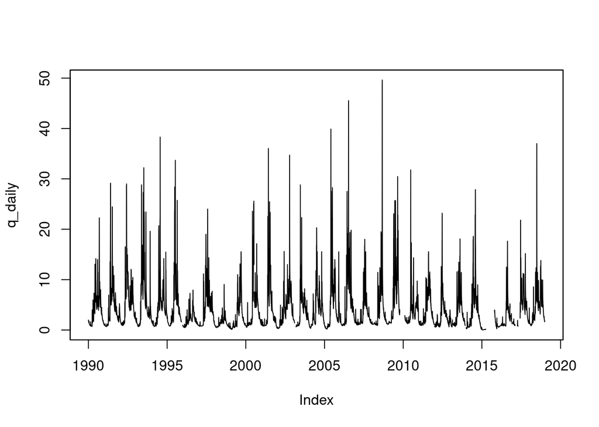

```r
plot(q_daily)
```

Ahora podemos convertir la serie temporal diaria en una serie temporal mensual. Aquí usaremos la función **mean** y el argumento *FUN* ya que queremos obtener el caudal mensual en m$^3$/s.

```r
q_monthly <- daily2monthly(q_daily, FUN = mean, na.rm = TRUE)
summary(q_monthly)
```

```
##      Index              q_monthly
##  Min.   :1990-01-01   Min.   : 0.06076
##  1st Qu.:1997-03-24   1st Qu.: 1.19137
##  Median :2004-06-16   Median : 2.48958
##  Mean   :2004-06-16   Mean   : 3.86081
##  3rd Qu.:2011-09-08   3rd Qu.: 5.65717
##  Max.   :2018-12-01   Max.   :15.44473
##                       NA's   :11
```

Podemos trazar el objeto zoo resultante para visualizar la serie temporal.

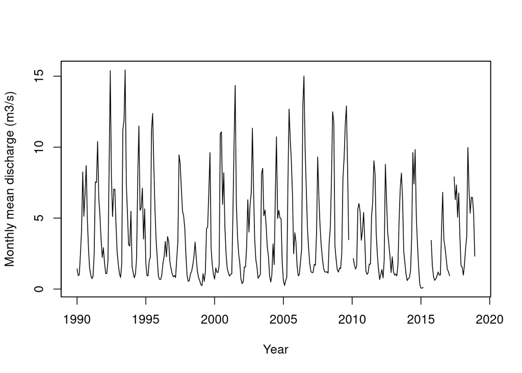

```r
plot(q_monthly, xlab = "Year", ylab = "Monthly mean discharge (m3/s)")
```

**Parte B**

Extraigamos los datos de cada estación.

```r
q_djf <- hydroTSM::extract(q_daily, trgt = "DJF")
q_mam <- hydroTSM::extract(q_daily, trgt = "MAM")
q_jja <- hydroTSM::extract(q_daily, trgt = "JJA")
q_son <- hydroTSM::extract(q_daily, trgt = "SON")
```

Podemos graficar el objeto *q_djf* para visualizar los resultados.

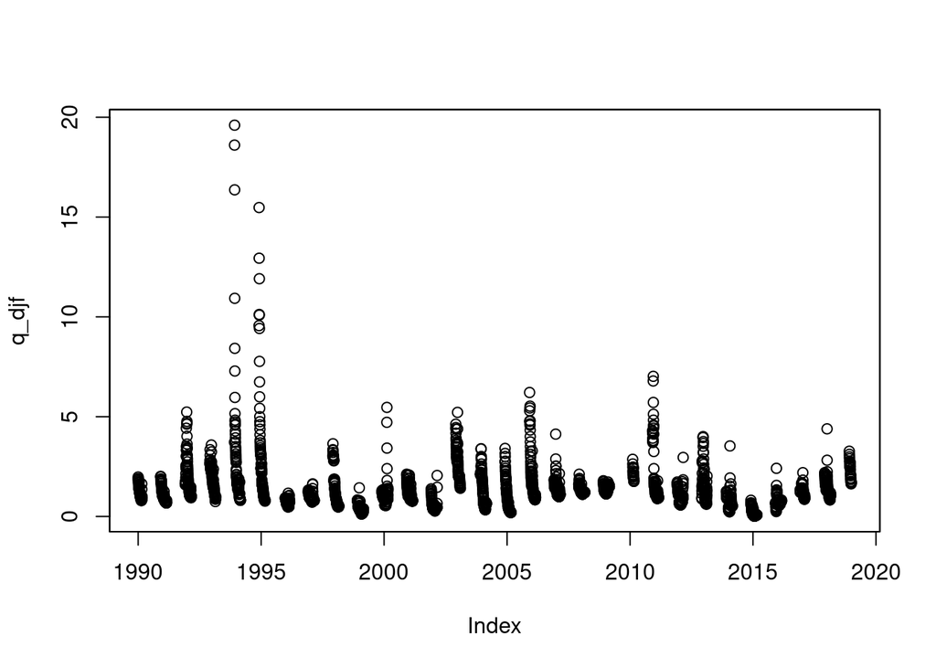

```r
plot(q_djf, type = "p")
```

Calculamos el caudal estacional medio.

```r
mean_djf <- mean(q_djf, na.rm = TRUE)
mean_mam <- mean(q_mam, na.rm = TRUE)
mean_jja <- mean(q_jja, na.rm = TRUE)
mean_son <- mean(q_son, na.rm = TRUE)
```

Finalmente, podemos imprimir los resultados del paso anterior.

```r
print(mean_djf)
```

```
## [1] 1.366668
```

```r
print(mean_mam)
```

```
## [1] 2.043858
```

```r
print(mean_jja)
```

```
## [1] 7.716251
```

```r
print(mean_son)
```

```
## [1] 4.379506
```

## Referencias

- Mu, Qiaozhen, Faith Ann Heinsch, Maosheng Zhao, and Steven W Running. 2007. “Development of a Global Evapotranspiration Algorithm Based on Modis and Global Meteorology Data.” Remote Sensing of Environment 111 (4). Elsevier: 519–36.
- Mu, Qiaozhen, M Zhao, and SW Running. 2011. “Improvements and Evaluations of the Modis Global Evapotranspiration Algorithm.” Remote Sensing of Environment 115 (8): 1781–1800.
- Running, Steven W, Qiaozhen Mu, Maosheng Zhao, and Alvaro Moreno. 2017. “MODIS Global Terrestrial Evapotranspiration (et) Product (Nasa Mod16a2/A3) Nasa Earth Observing System Modis Land Algorithm.” NASA: Washington, DC, USA.
- Senay, Gabriel B, Stefanie Bohms, Ramesh K Singh, Prasanna H Gowda, Naga M Velpuri, Henok Alemu, and James P Verdin. 2013. “Operational Evapotranspiration Mapping Using Remote Sensing and Weather Datasets: A New Parameterization for the Sseb Approach.” JAWRA Journal of the American Water Resources Association 49 (3). Wiley Online Library: 577–91.